# Text Mining

03-03-2020

# Text Mining

There are quite a number of R packages for doing text mining. For example,

- tm
- quanteda
- tidytext
- corpus
- koRpus

See here for a nice comparsion between the packages: https://quanteda.io/articles/pkgdown/comparison.html

We will focus on `tidytext` for its simplicity.

So what do we do with text mining?

(from https://www.linguamatics.com/) > Text mining (also referred to as text analytics) is an artificial intelligence (AI) technology that uses natural language processing (NLP) to transform the free (unstructured) text in documents and databases into normalized, structured data suitable for analysis or to drive machine learning (ML) algorithms.

(Disclaimer: I am not an expert of NLP or text mining)

# Data structures

Text data often are stored in the following ways

- String: Text can, of course, be stored as strings, i.e., character vectors, within R, and often text data is first read into memory in this form.
- Corpus: These types of objects typically contain raw strings annotated with additional metadata and details.
- Document-term matrix: This is a sparse matrix describing a collection (i.e., a corpus) of documents with one row for each document and one column for each term. The value in the matrix is typically word count or tf-idf

```r
library(tidyverse)
library(tidytext)
```

```r
# A poem by Emily Dickinson
text <- c("Because I could not stop for Death -",
          "He kindly stopped for me -",
          "The Carriage held but just Ourselves -",
          "and Immortality")
df <- tibble(line = 1:4, text = text)
```

We want to convert the data frame so that it has one-token-per-document-per-row.

```r
df %>%
  unnest_tokens(word, text)
```

| line | word |
| --- | --- |
| 1 | because |
| 1 | i |
| 1 | could |
| 1 | not |
| 1 | stop |
| 1 | for |
| 1 | death |
| 2 | he |
| 2 | kindly |
| 2 | stopped |

[output cut: 10 more lines]

After using `unnest_tokens`, we’ve split each row so that there is one token (word) in each row of the new data frame; the default tokenization in `unnest_tokens()` is for single words (unigram), as shown here. Also notice:

- Other columns, such as the line number each word came from, are retained.
- Punctuation has been stripped.
- By default, `unnest_tokens()` converts the tokens to lowercase, which makes them easier to compare or combine with other datasets. (Use the `to_lower = FALSE` argument to turn off this behavior).

Often in text analysis, we will want to remove stop words; stop words are words that are not useful for an analysis, typically extremely common words such as “the”, “of”, “to”, and so forth in English.

```r
data(stop_words)
stop_words
```

| word | lexicon |
| --- | --- |
| a | SMART |
| a's | SMART |
| able | SMART |
| about | SMART |
| above | SMART |
| according | SMART |
| accordingly | SMART |
| across | SMART |
| actually | SMART |
| after | SMART |

[output cut: 90 more lines]

```r
df %>%
  unnest_tokens(word, text) %>%
  anti_join(stop_words)
```

| line | word |
| --- | --- |
| 1 | stop |
| 1 | death |
| 2 | kindly |
| 2 | stopped |
| 3 | carriage |
| 3 | held |
| 4 | immortality |

```r
library(rvest)
```

Try to read some news headlines from yahoo

```r
h3 <- read_html("http://news.yahoo.com/") %>%
  html_nodes("h3")

news_df <- tibble(
    title = h3 %>% html_text(),
    url = h3 %>%  html_node("a") %>% html_attr("href")
  ) %>%
  filter(str_starts(url, "/")) %>%
  mutate(url = str_c("http://news.yahoo.com", url), id = sprintf("%02d", row_number())) %>%
  head(20)
```

Read the contents

```r
news_content <- NULL
for (i in seq_len(nrow(news_df))) {
  news_content <- bind_rows(
    news_content,
    read_html(news_df$url[i]) %>%
      html_nodes("article p") %>%
      html_text() %>% {
        tibble(id = news_df$id[i], text = c(news_df$title[i], .))
      }
  )
}
```

```r
news_tokens <- news_content %>%
  unnest_tokens(word, text) %>%
  anti_join(stop_words) %>%
  group_by(id) %>%
  count(word, sort = TRUE) %>%
  arrange(id)
(news_propotions <- news_tokens %>%
  group_by(id) %>%
  mutate(propotion = n / sum(n)) %>%
  select(-n) %>%
  arrange(id, desc(propotion)))
```

| id | word | propotion |
| --- | --- | --- |
| 01 | sanders | 0.042979943 |
| 01 | win | 0.025787966 |
| 01 | biden | 0.020057307 |
| 01 | candidate | 0.017191977 |
| 01 | election | 0.014326648 |
| 01 | nomination | 0.014326648 |
| 01 | race | 0.014326648 |
| 01 | democratic | 0.011461318 |
| 01 | disastrous | 0.011461318 |
| 01 | trump | 0.011461318 |

[output cut: 90 more lines]

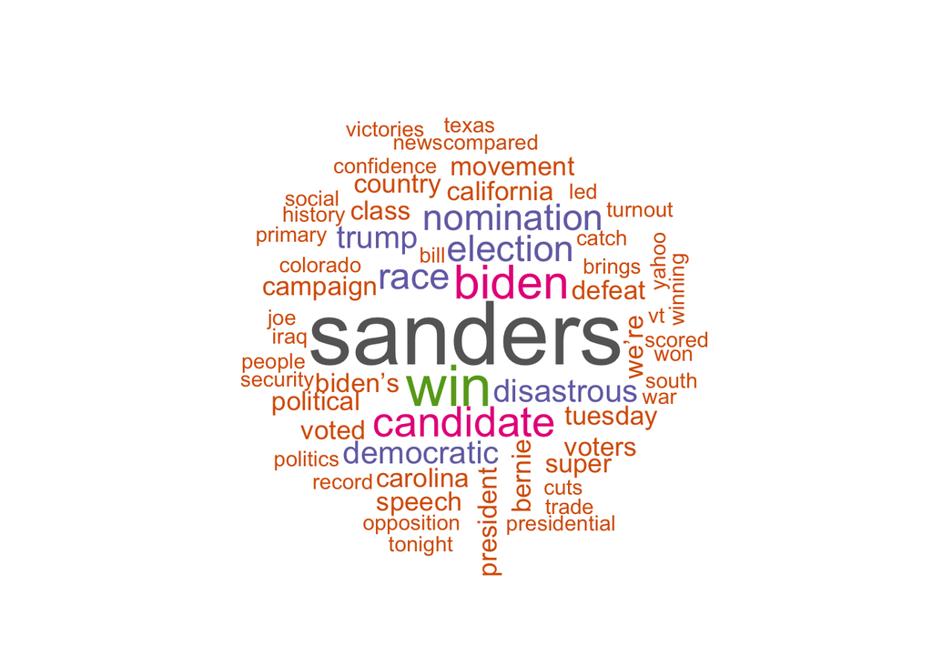

```r
library(wordcloud)
news_tokens %>%
  filter(id == "01") %>%
  with(wordcloud(
    word, n, min.freq = 2, max.words = 100, random.order = FALSE,
    colors = brewer.pal(8, "Dark2")))
```

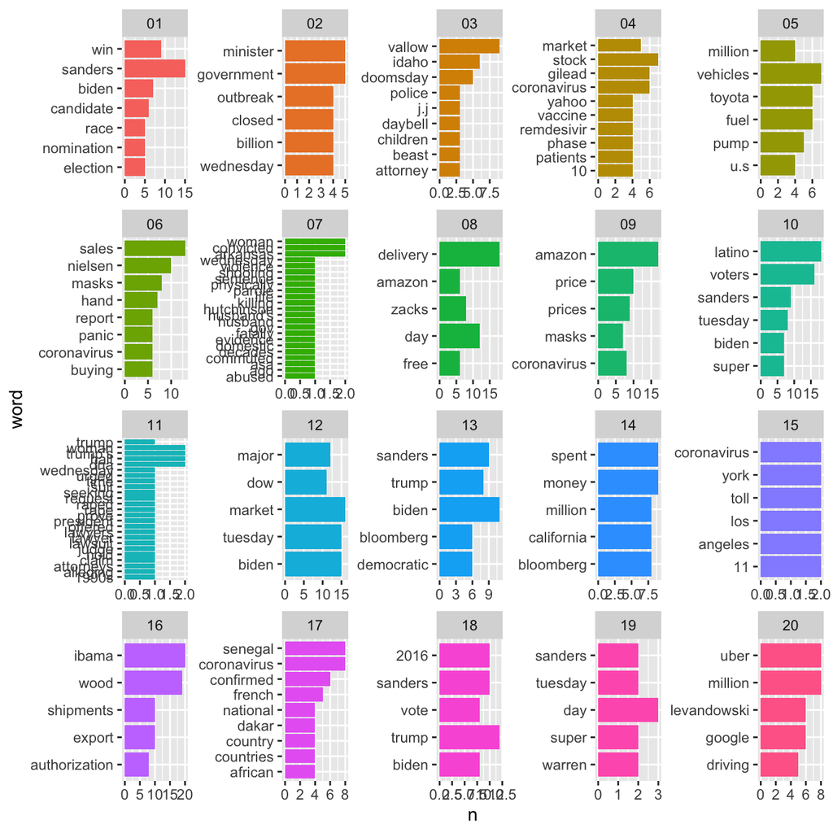

```r
news_tokens %>%
  top_n(5, n) %>%
  ggplot(aes(x = fct_reorder(word, n), y = n, fill = id)) +
      geom_bar(stat = "identity", na.rm = TRUE, show.legend = FALSE) +
      xlab("word") +
      facet_wrap(~id, scales = "free") +
      coord_flip()
```

The order the categories in each facet are not ordered correctly. Following https://drsimonj.svbtle.com/ordering-categories-within-ggplot2-facets, I got the following fix.

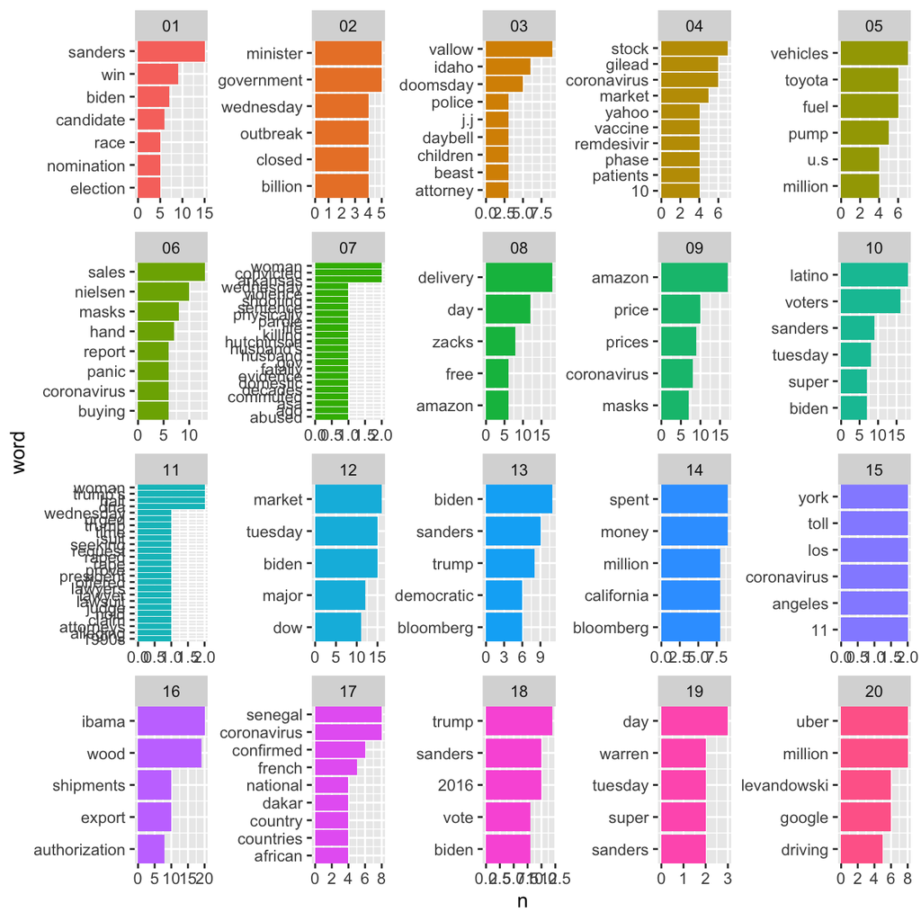

```r
news_tokens %>%
  top_n(5, n) %>%
  ungroup() %>%
  arrange(id, n) %>%
  mutate(order = row_number()) %>% {
    ggplot(., aes(x = order, y = n, fill = id)) +
      geom_bar(stat = "identity", na.rm = TRUE, show.legend = FALSE) +
      xlab("word") +
      facet_wrap(~id, scales = "free") +
      coord_flip() +
      scale_x_continuous(breaks = .$order, labels = .$word, expand = c(0, 0))
  }
```

## Sentiment analysis

The `tidytext` package contains several sentiment lexicons. Three general-purpose lexicons are

- `AFINN` from Finn Årup Nielsen,
- `bing` from Bing Liu and collaborators, and
- `nrc` from Saif Mohammad and Peter Turney.

All three of these lexicons are based on unigrams, i.e., single words. These lexicons contain many English words and the words are assigned scores for positive/negative sentiment, and also possibly emotions like joy, anger, sadness, and so forth. It is important to keep in mind that these methods do not take into account qualifiers before a word, such as in “no good” or “not true”; a lexicon-based method like this is based on unigrams only.

```r
library(textdata)

get_sentiments("afinn")
```

| word | value |
| --- | --- |
| abandon | -2 |
| abandoned | -2 |
| abandons | -2 |
| abducted | -2 |
| abduction | -2 |
| abductions | -2 |
| abhor | -3 |
| abhorred | -3 |
| abhorrent | -3 |
| abhors | -3 |

[output cut: 90 more lines]

```r
get_sentiments("bing")
```

| word | sentiment |
| --- | --- |
| 2-faces | negative |
| abnormal | negative |
| abolish | negative |
| abominable | negative |
| abominably | negative |
| abominate | negative |
| abomination | negative |
| abort | negative |
| aborted | negative |
| aborts | negative |

[output cut: 90 more lines]

```r
get_sentiments("nrc")
```

| word | sentiment |
| --- | --- |
| abacus | trust |
| abandon | fear |
| abandon | negative |
| abandon | sadness |
| abandoned | anger |
| abandoned | fear |
| abandoned | negative |
| abandoned | sadness |
| abandonment | anger |
| abandonment | fear |

[output cut: 90 more lines]

```r
news_tokens %>%
  left_join(get_sentiments("bing")) %>%
  group_by(id) %>%
  summarize(
    positive = sum(sentiment == "positive", na.rm = TRUE),
    negative = sum(sentiment == "negative", na.rm = TRUE),
    netural = n() - positive - negative) %>%
  mutate(
    id,
    sentiment = case_when(
      positive > negative ~ "positive",
      positive < negative ~ "negative",
      TRUE ~ "netural"
    )
  ) %>%
  left_join(select(news_df, id, title)) %>%
  mutate(title = str_trunc(title, 80)) %>%
  select(sentiment, title)
```

| sentiment | title |
| --- | --- |
| positive | Bernie Sanders unloads on Joe Biden as Super Tuesday makes it a two-man race |
| negative | Coronavirus death toll jumps to 107 in Italy, all schools shut |
| negative | Doomsday Mom Invokes the Fifth as She’s Extradited to Idaho |
| positive | Coronavirus vaccine could add billions in value to this one stock |
| negative | Toyota recalls 3.2 million vehicles worldwide over fuel pump problem |
| negative | Coronavirus concerns lead to hoarding, panic buying to stock 'panic pantries,... |
| negative | Arkansas woman convicted in husband's killing to get parole after evidence of... |
| positive | Coronavirus Scare Spikes Online Orders, Amazon Sparks Delivery War |
| negative | Coronavirus price gouging: 3 charts show Amazon's wild spikes |
| positive | Sanders's wins on Super Tuesday show power of Latino vote |

[output cut: 10 more lines]

# Analyzing word and document frequency: tf-idf

A central question in text mining and natural language processing is how to quantify what a document is about. One measure of how important a word may be is its term frequency. Another approach is to look at a term’s inverse document frequency (idf), which decreases the weight for commonly used words and increases the weight for words that are not used very much.

$$\text{idf} = \ln\left(\frac{n_{\text{documents}}}{n_{\text{documents containing term}}} \right)$$

$$\text{tf_idf} = \text{tf} \times \text{idf}$$

Show the 3 most important words in each document.

```r
news_tokens %>%
  bind_tf_idf(word, id, n) %>%
  top_n(3, tf_idf) %>%
  select(id, word, n, tf_idf)
```

| id | word | n | tf_idf |
| --- | --- | --- | --- |
| 01 | sanders | 15 | 0.04512129 |
| 01 | win | 9 | 0.03574971 |
| 01 | disastrous | 4 | 0.02639066 |
| 02 | minister | 5 | 0.04354262 |
| 02 | closed | 4 | 0.02677425 |
| 02 | decree | 3 | 0.02612557 |
| 02 | events | 3 | 0.02612557 |
| 02 | schools | 3 | 0.02612557 |
| 03 | vallow | 9 | 0.14042495 |
| 03 | idaho | 6 | 0.09361663 |

[output cut: 61 more lines]

Using term frequency and inverse document frequency allows us to find words that are characteristic for one document within a collection of documents.

## n-grams

We’ve been using the unnest_tokens function to tokenize by word, or sometimes by sentence, which is useful for the kinds of sentiment and frequency analyses we’ve been doing so far. But we can also use the function to tokenize into consecutive sequences of words, called n-grams.

We try to study the bigrams in Derivative wiki page.

```r
derivative_bigrams <- read_html("https://en.wikipedia.org/wiki/Derivative") %>%
  html_nodes("p") %>%
  html_text() %>%
  tibble(text = .) %>%
  unnest_tokens(bigram, text, token = "ngrams", n = 2) %>%
  separate(bigram, c("word1", "word2"), sep = " ") %>%
  anti_join(stop_words, by = c("word1" = "word")) %>%
  anti_join(stop_words, by = c("word2" = "word")) %>%
  unite(bigram, sep = " ")
```

```r
derivative_bigrams %>%
  count(bigram, sort = TRUE)
```

| bigram | n |
| --- | --- |
| difference quotient | 18 |
| total derivative | 17 |
| linear approximation | 15 |
| partial derivatives | 12 |
| valued function | 11 |
| directional derivative | 10 |
| linear transformation | 10 |
| tangent line | 10 |
| approximation formula | 6 |
| real valued | 6 |

[output cut: 90 more lines]

Back to the news

```r
news_content %>%
  unnest_tokens(bigram, text, token = "ngrams", n = 2) %>%
  separate(bigram, c("word1", "word2"), sep = " ") %>%
  anti_join(stop_words, by = c("word1" = "word")) %>%
  anti_join(stop_words, by = c("word2" = "word")) %>%
  group_by(id) %>%
  count(word1, word2, sort = TRUE) %>%
  arrange(id)
```

| id | word1 | word2 | n |
| --- | --- | --- | --- |
| 01 | democratic | nomination | 3 |
| 01 | super | tuesday | 3 |
| 01 | bernie | sanders | 2 |
| 01 | candidate | voted | 2 |
| 01 | disastrous | trade | 2 |
| 01 | joe | biden | 2 |
| 01 | political | movement | 2 |
| 01 | social | security | 2 |
| 01 | south | carolina | 2 |
| 01 | yahoo | news | 2 |

[output cut: 90 more lines]

# Using bigrams to provide context in sentiment analysis

Our sentiment analysis approach above simply counted the appearance of positive or negative words. One of the problems with this approach is that a word’s context can matter nearly as much as its presence. For example, the words “happy” and “like” will be counted as positive, even in a sentence like “I’m not happy and I don’t like it!”

```r
# stop words are not removed in this case
news_tokens2 <- news_content %>%
  unnest_tokens(bigram, text, token = "ngrams", n = 2) %>%
  separate(bigram, c("word1", "word2"), sep = " ")
```

Back to the sentiment analysis

```r
negate_words <- c("not", "without", "no", "can't", "don't", "won't")

news_tokens2 %>%
  group_by(id) %>%
  count(word1, word2) %>%
  left_join(get_sentiments("bing"), by = c("word2" = "word")) %>%
  mutate(sentiment = case_when(
    word1 %in% negate_words & sentiment == "negative" ~ "positive",
    word1 %in% negate_words & sentiment == "positive" ~ "negative",
    TRUE ~ sentiment)) %>%
  summarize(
    positive = sum(sentiment == "positive", na.rm = TRUE),
    negative = sum(sentiment == "negative", na.rm = TRUE),
    netural = n() - positive - negative) %>%
  mutate(
    id,
    sentiment = case_when(
      positive > negative ~ "positive",
      positive < negative ~ "negative",
      TRUE ~ "netural"
    )
  ) %>%
  left_join(select(news_df, id, title)) %>%
  mutate(title = str_trunc(title, 80)) %>%
  select(sentiment, title)
```

| sentiment | title |
| --- | --- |
| positive | Bernie Sanders unloads on Joe Biden as Super Tuesday makes it a two-man race |
| negative | Coronavirus death toll jumps to 107 in Italy, all schools shut |
| negative | Doomsday Mom Invokes the Fifth as She’s Extradited to Idaho |
| positive | Coronavirus vaccine could add billions in value to this one stock |
| negative | Toyota recalls 3.2 million vehicles worldwide over fuel pump problem |
| negative | Coronavirus concerns lead to hoarding, panic buying to stock 'panic pantries,... |
| negative | Arkansas woman convicted in husband's killing to get parole after evidence of... |
| positive | Coronavirus Scare Spikes Online Orders, Amazon Sparks Delivery War |
| negative | Coronavirus price gouging: 3 charts show Amazon's wild spikes |
| positive | Sanders's wins on Super Tuesday show power of Latino vote |

[output cut: 10 more lines]

## Cluster analysis

> Cluster analysis or clustering is the task of grouping a set of objects in such a way that objects in the same group (called a cluster) are more similar (in some sense) to each other than to those in other groups (clusters)

First, we will need to define similarity. One way to quantity how similar two documents are is the cosine distance.

Compare to regular euclidean distance, it is more situable for sparse vectors.

```r
library(proxy)
docsdissim <- dist(as.matrix(cast_dtm(news_tokens, id, word, n)), method = "cosine")
```

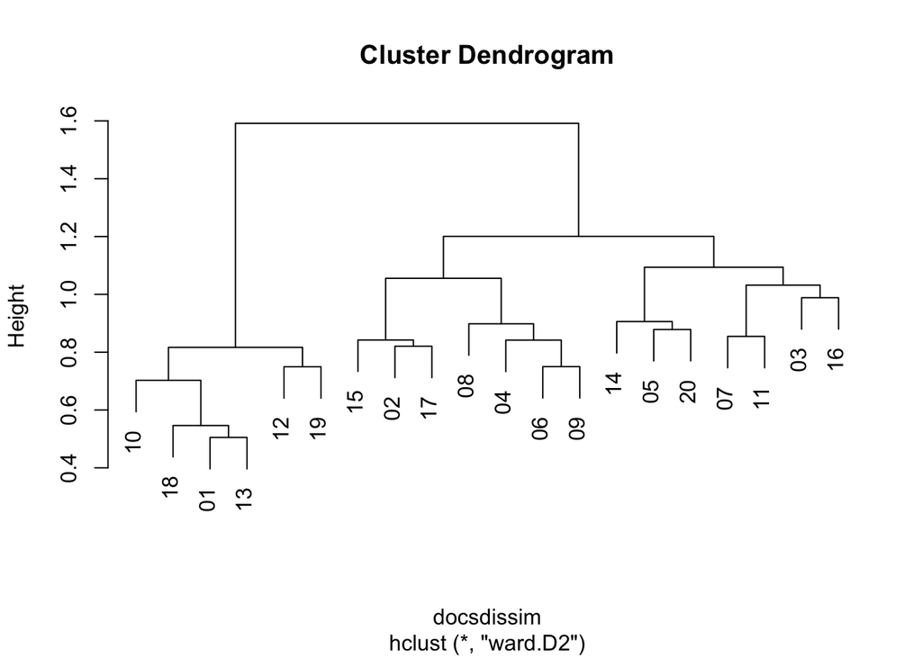

```r
h <- hclust(docsdissim, method = "ward.D2")
plot(h)
```

We could use `cutree` to pick the number of groups.

```r
tibble(topic = cutree(h, k = 3), title = news_df$title) %>%
  arrange(topic) %>%
  mutate(title = str_trunc(title, 80)) %>%
  select(topic, title)
```

| topic | title |
| --- | --- |
| 1 | Bernie Sanders unloads on Joe Biden as Super Tuesday makes it a two-man race |
| 1 | Sanders's wins on Super Tuesday show power of Latino vote |
| 1 | Stock market news live: Stocks boosted by Super Tuesday results; Coronavirus ... |
| 1 | Biden goes from rags to riches |
| 1 | 2020 Democrats learned the lesson of Trump's GOP takeover: Unite or die |
| 1 | Warren weighs her options after Super Tuesday results. Endorsing Sanders is p... |
| 2 | Coronavirus death toll jumps to 107 in Italy, all schools shut |
| 2 | Coronavirus vaccine could add billions in value to this one stock |
| 2 | Coronavirus concerns lead to hoarding, panic buying to stock 'panic pantries,... |
| 2 | Coronavirus Scare Spikes Online Orders, Amazon Sparks Delivery War |

[output cut: 10 more lines]

In cluster analysis, we only assign a single topic to a single document. In reality, a single document may contain multiple topics.

## LDA

Latent Dirichlet allocation is one of the most common algorithms for topic modeling. Without diving into the math behind the model, we can understand it as being guided by two principles.

- Every topic is a mixture of words
- Every document is a mixture of topics

```r
library(topicmodels)
```

We want to allocate the topics and documents into 4 different topics.

```r
news_lda <- LDA(
  cast_dtm(news_tokens, id, word, n),
  k = 4,
  control = list(seed = 1234))
```

### Word-topic probabilities

The following table shows the probability of a specific term occurring in a topic.

```r
tidy(news_lda, matrix = "beta") %>%
  group_by(topic) %>%
  top_n(10, beta) %>%
  arrange(topic, desc(beta))
```

| topic | term | beta |
| --- | --- | --- |
| 1 | sanders | 0.023655405 |
| 1 | biden | 0.019264601 |
| 1 | trump | 0.014990437 |
| 1 | win | 0.010491295 |
| 1 | democratic | 0.008992651 |
| 1 | bloomberg | 0.008328122 |
| 1 | campaign | 0.008324688 |
| 1 | yahoo | 0.007767667 |
| 1 | race | 0.007560341 |
| 1 | voters | 0.007097495 |

[output cut: 30 more lines]

### Document-topic probabilities

The following table shows the probability of a specific topic occurring in a document.

```r
# t is the variable `alpha` on the wikipedia page of LDA
tidy(news_lda, matrix = "gamma") %>%
    pivot_wider(names_from = topic, values_from = gamma)
```

| document | 1 | 2 | 3 | 4 |
| --- | --- | --- | --- | --- |
| 01 | 9.997510e-01 | 8.301623e-05 | 8.301623e-05 | 8.301623e-05 |
| 02 | 8.422246e-05 | 8.422246e-05 | 9.997473e-01 | 8.422246e-05 |
| 03 | 1.508583e-04 | 1.508583e-04 | 9.995474e-01 | 1.508583e-04 |
| 04 | 1.232681e-04 | 9.996302e-01 | 1.232681e-04 | 1.232681e-04 |
| 05 | 2.335098e-04 | 9.992995e-01 | 2.335098e-04 | 2.335098e-04 |
| 06 | 6.981734e-05 | 9.997905e-01 | 6.981734e-05 | 6.981734e-05 |
| 07 | 9.966707e-01 | 1.109755e-03 | 1.109755e-03 | 1.109755e-03 |
| 08 | 7.118928e-05 | 9.997864e-01 | 7.118928e-05 | 7.118928e-05 |
| 09 | 7.705680e-05 | 9.997688e-01 | 7.705680e-05 | 7.705680e-05 |
| 10 | 1.566472e-01 | 6.676164e-05 | 8.432193e-01 | 6.676164e-05 |

[output cut: 10 more lines]

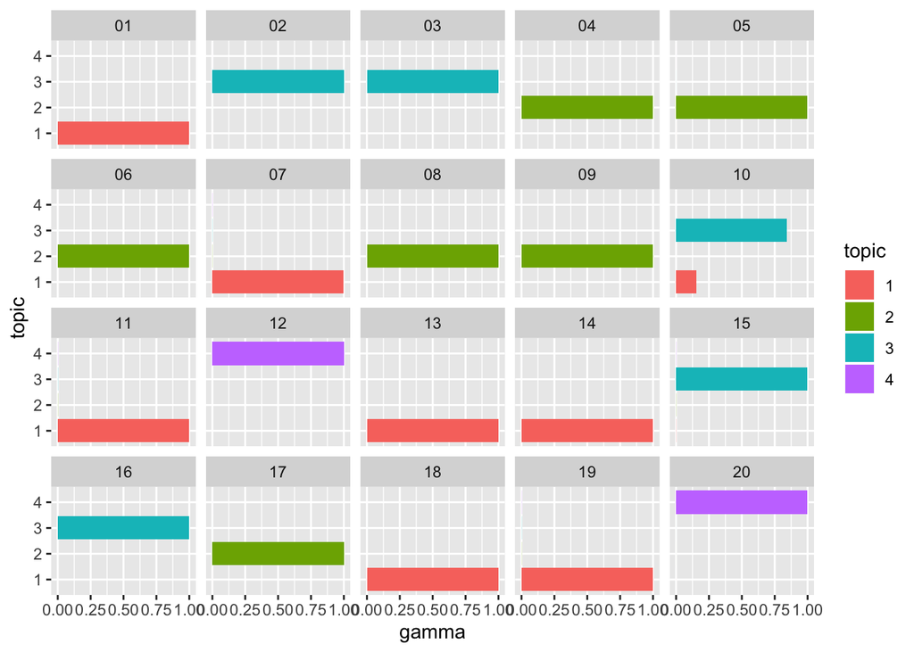

```r
tidy(news_lda, "gamma") %>%
  mutate(topic = as_factor(topic)) %>%
  ggplot(aes(topic, gamma, fill = topic)) +
  geom_bar(stat = "identity") +
  facet_wrap(~document, 4) +
  coord_flip()
```

## CTM

Correlated topic model is an extension of LDA which supports correlations between topics.

```r
news_ctm <- CTM(
  cast_dtm(news_tokens, id, word, n),
  k = 4,
  control = list(seed = 1234) )
```

```r
tidy(news_ctm, matrix = "beta") %>%
  group_by(topic) %>%
  top_n(10, beta) %>%
  arrange(topic, desc(beta))
```

| topic | term | beta |
| --- | --- | --- |
| 1 | ibama | 0.013279928 |
| 1 | wood | 0.012615931 |
| 1 | delivery | 0.011951935 |
| 1 | day | 0.008631979 |
| 1 | coronavirus | 0.008630897 |
| 1 | amazon | 0.007967959 |
| 1 | stock | 0.007303972 |
| 1 | export | 0.006639964 |
| 1 | shipments | 0.006639964 |
| 1 | zacks | 0.005311971 |

[output cut: 31 more lines]

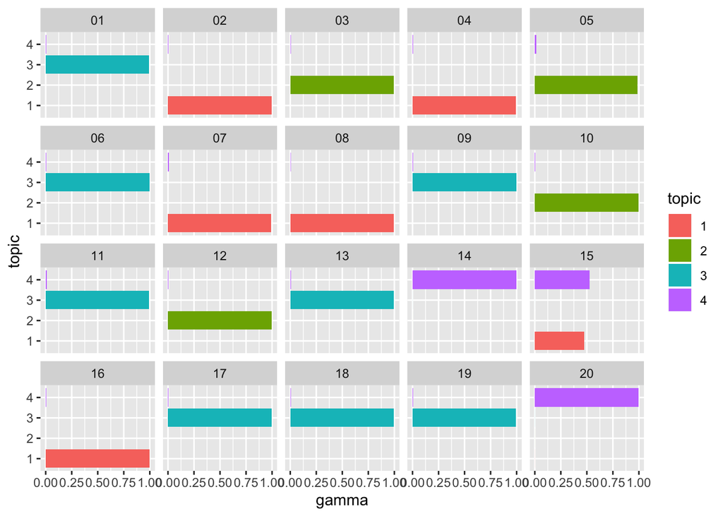

```r
tidy(news_ctm, "gamma") %>%
  mutate(topic = as_factor(topic)) %>%
  ggplot(aes(topic, gamma, fill = topic)) +
  geom_bar(stat = "identity") +
  facet_wrap(~document, 4) +
  coord_flip()
```

# Reference:

- Tidytext: https://www.tidytextmining.com/